# Prosper Loan Data Exploration

## Preliminary Wrangling

This document explores the 'Prosper Loan Data' dataset. This data set contains 113,937 loans with 81 variables on each loan, including loan amount, borrower rate (or interest rate), current loan status, borrower income, and many others.

```python
# import all packages and set plots to be embedded inline
import numpy as np
import pandas as pd
import matplotlib.pyplot as plt
import matplotlib.gridspec as gridspec
import seaborn as sb

%matplotlib inline
```

> Load in your dataset and describe its properties through the questions below. Try and motivate your exploration goals through this section.

```python
loans = pd.read_csv('prosperLoanData.csv')
```

```python
print(loans.shape)
print(loans.dtypes)
print(loans.head(10))
```

```
(113937, 81)
ListingKey                              object
ListingNumber                            int64
ListingCreationDate                     object
CreditGrade                             object
Term                                     int64
LoanStatus                              object
ClosedDate                              object
BorrowerAPR                            float64
BorrowerRate                           float64
LenderYield                            float64
EstimatedEffectiveYield                float64
EstimatedLoss                          float64
EstimatedReturn                        float64
ProsperRating (numeric)                float64
ProsperRating (Alpha)                   object
ProsperScore                           float64
ListingCategory (numeric)                int64
BorrowerState                           object
Occupation                              object
EmploymentStatus                        object
EmploymentStatusDuration               float64
IsBorrowerHomeowner                       bool
CurrentlyInGroup                          bool
GroupKey                                object
DateCreditPulled                        object
CreditScoreRangeLower                  float64
CreditScoreRangeUpper                  float64
FirstRecordedCreditLine                 object
CurrentCreditLines                     float64
OpenCreditLines                        float64
                                        ...
TotalProsperLoans                      float64
TotalProsperPaymentsBilled             float64
OnTimeProsperPayments                  float64
ProsperPaymentsLessThanOneMonthLate    float64
ProsperPaymentsOneMonthPlusLate        float64
ProsperPrincipalBorrowed               float64
ProsperPrincipalOutstanding            float64
ScorexChangeAtTimeOfListing            float64
```

[output cut: 81 more lines]

```
9            1.0                0                          0

  InvestmentFromFriendsAmount Investors
0                         0.0       258
1                         0.0         1
2                         0.0        41
3                         0.0       158
4                         0.0        20
5                         0.0         1
6                         0.0         1
7                         0.0         1
8                         0.0         1
9                         0.0         1

[10 rows x 81 columns]
```

```python
print(loans.describe())
```

```
       ListingNumber           Term    BorrowerAPR   BorrowerRate  \
count   1.139370e+05  113937.000000  113912.000000  113937.000000
mean    6.278857e+05      40.830248       0.218828       0.192764
std     3.280762e+05      10.436212       0.080364       0.074818
min     4.000000e+00      12.000000       0.006530       0.000000
25%     4.009190e+05      36.000000       0.156290       0.134000
50%     6.005540e+05      36.000000       0.209760       0.184000
75%     8.926340e+05      36.000000       0.283810       0.250000
max     1.255725e+06      60.000000       0.512290       0.497500

         LenderYield  EstimatedEffectiveYield  EstimatedLoss  EstimatedReturn  \
count  113937.000000             84853.000000   84853.000000     84853.000000
mean        0.182701                 0.168661       0.080306         0.096068
std         0.074516                 0.068467       0.046764         0.030403
min        -0.010000                -0.182700       0.004900        -0.182700
25%         0.124200                 0.115670       0.042400         0.074080
50%         0.173000                 0.161500       0.072400         0.091700
75%         0.240000                 0.224300       0.112000         0.116600
max         0.492500                 0.319900       0.366000         0.283700

       ProsperRating (numeric)  ProsperScore  ...  LP_ServiceFees  \
count             84853.000000  84853.000000  ...   113937.000000
mean                  4.072243      5.950067  ...      -54.725641
std                   1.673227      2.376501  ...       60.675425
min                   1.000000      1.000000  ...     -664.870000
25%                   3.000000      4.000000  ...      -73.180000
50%                   4.000000      6.000000  ...      -34.440000
75%                   5.000000      8.000000  ...      -13.920000
max                   7.000000     11.000000  ...       32.060000

       LP_CollectionFees  LP_GrossPrincipalLoss  LP_NetPrincipalLoss  \
count      113937.000000          113937.000000        113937.000000
mean          -14.242698             700.446342           681.420499
std           109.232758            2388.513831          2357.167068
min         -9274.750000             -94.200000          -954.550000
25%             0.000000               0.000000             0.000000
50%             0.000000               0.000000             0.000000
75%             0.000000               0.000000             0.000000
max             0.000000           25000.000000         25000.000000

       LP_NonPrincipalRecoverypayments  PercentFunded  Recommendations  \
count                    113937.000000  113937.000000    113937.000000
mean                         25.142686       0.998584         0.048027
std                         275.657937       0.017919         0.332353
min                           0.000000       0.700000         0.000000
25%                           0.000000       1.000000         0.000000
50%                           0.000000       1.000000         0.000000
75%                           0.000000       1.000000         0.000000
max                       21117.900000       1.012500        39.000000

       InvestmentFromFriendsCount  InvestmentFromFriendsAmount      Investors
count               113937.000000                113937.000000  113937.000000
mean                     0.023460                    16.550751      80.475228
std                      0.232412                   294.545422     103.239020
min                      0.000000                     0.000000       1.000000
25%                      0.000000                     0.000000       2.000000
50%                      0.000000                     0.000000      44.000000
75%                      0.000000                     0.000000     115.000000
max                     33.000000                 25000.000000    1189.000000

[8 rows x 61 columns]
```

```python
loans['ListingCategory (numeric)'].unique()
```

```
array([ 0,  2, 16,  1,  7, 13,  6, 15, 20, 19,  3, 18,  8,  4, 11, 14,  5,
        9, 17, 10, 12], dtype=int64)
```

### What is the structure of your dataset?

There are 113,937 loans in the dataset with 81 attributes each. A description of these attributes can be foun't [here](https://docs.google.com/spreadsheets/d/1gDyi_L4UvIrLTEC6Wri5nbaMmkGmLQBk-Yx3z0XDEtI/edit?usp=sharing). Most of these are numeric.

The ProsperRating variable is ordinal, it is sorted from worst to best.

**ProsperRating (alpha)**: N/A, HR, E, D, C, B, A, AA. (N/A is not part of the ordening).

The ListingCategory and EmploymentStatus are categorical variables.

**Listing Category**: 0 - Not Available, 1 - Debt Consolidation, 2 - Home Improvement, 3 - Business, 4 - Personal Loan, 5 - Student Use, 6 - Auto, 7- Other, 8 - Baby&Adoption, 9 - Boat, 10 - Cosmetic Procedure, 11 - Engagement Ring, 12 - Green Loans, 13 - Household Expenses, 14 - Large Purchases, 15 - Medical/Dental, 16 - Motorcycle, 17 - RV, 18 - Taxes, 19 - Vacation, 20 - Wedding Loans. (it will be best change the numbers in the dataset to the corresponding strings. This will make created visuals more clear to read).

**EmploymentStatus**: Self-employed, Employed, Not available, Full-time, Other, nan, Not Employed, Part-time, Retired.

Because there are so many variables this exploration will focus on only 10-15 of them.

### What is/are the main feature(s) of interest in your dataset?

The main interest of this exploration is to discover which features are best used to predict if a loan will be completed.

### What features in the dataset do you think will help support your investigation into your feature(s) of interest?

There are several variables that probably have an effect on the completion rate of the loans.

```
1.LoanStatus: this variable is needed to check the status of the loan.
2.Recommendations: we can expect that the higher the amount of recommendations, the higher the chance that the loan will be completed.
3. DebtToIncomeRatio: we can expect that a higher DebtToIncomeRatio will lead to a higher chance that a loan will not be completed.
4. IncomeVerifiable: if this value is false, we can expect that the chance is lower that the loan wil be completed.
5. StatedMonthlyIncome: we can expect that the higher this variable, the higher the chance that a loan will be completed.
6. ProsperScore: we can expect that the higher this score, the higher the chance a loan will be completed.
7. ProsperRating (alpha): we can expect that this variable will behave fairly analog to the ProsperScore.
8. Term: the length of the loan expressed in months. It is to be expected that the higher this value, the higher the chance a loan will be completed.
9. BorrowerRate: we expect that the higher the rate is for the borrower, the higher the chance the loan will not be completed.
10. Listing Category: the category of the listing that the borrower selected when posting their listing. It is difficult to predict which effect this variable will have on the outcome of the loan.
11. EmploymentStatus: the employment status of the borrower at the time they posted the listing. It will be interesting to see which statuses have a positive effect on the outcome of a loan.
12. LoanOriginalAmount: the origination amount of the loan, we can expect this to be positively correlated with the StatedMonthlyIncome. This means there probably won't be a correlation between loan amount and loans completed.
```

## Data Cleaning

Before we start the data exploration process we will do some minimal cleaning on this dataset.

```
1. Convert the numeric values in Listing Category to their corresponding string values.
2. Convert ProsperRating (alpha) into an ordered categorical type.
3. Drop certain categories from the LoanStatus column. We are only interested in the 'Completed', 'Defaulted', 'Chargedoff' values. There are only 5 cancelled values, which is far too few, so these values will also be dropped.
4. There are values of 11 in the ProsperScore column, but the max should be 10.
```

```python
loans_clean = loans.copy()
```

```python
# Define: use dictionary to convert int values to string values in the 'ListingCategory (numeric) column'.

# Code:
list_dict = {0 : 'Not Available', 1 : 'Debt Consolidation', 2 : 'Home Improvement',
             3 : 'Business', 4 : 'Personal Loan', 5 : 'Student Use', 6 : 'Auto',
             7 : 'Other', 8 : 'Baby&Adoption', 9 : 'Boat', 10 : 'Cosmetic Procedure',
             11 : 'Engagement Ring', 12 : 'Green Loans', 13 : 'Household Expenses',
             14 : 'Large Purchases', 15 : 'Medical/Dental', 16 : 'Motorcycle',
             17 : 'RV', 18 : 'Taxes', 19 : 'Vacation', 20 : 'Wedding Loans'}
loans_clean['ListingCategory'] = loans_clean['ListingCategory (numeric)'].map(list_dict)
loans_clean.drop(['ListingCategory (numeric)'], axis=1, inplace=True)

# Test:
loans_clean.ListingCategory.head()
```

```
0       Not Available
1    Home Improvement
2       Not Available
3          Motorcycle
4    Home Improvement
Name: ListingCategory, dtype: object
```

```python
# Define: use a dictionary to convert 'ProsperRating (alpha)' into an ordered categorical type.

# Code:
ordinal_var_dict = {'ProsperRating (Alpha)': ['N/A', 'HR', 'E', 'D', 'C', 'B', 'A', 'AA']}

for var in ordinal_var_dict:
    ordered_var = pd.api.types.CategoricalDtype(ordered = True,
                                                categories = ordinal_var_dict[var])
    loans_clean[var] = loans[var].astype(ordered_var)

loans_clean.rename(columns={'ProsperRating (Alpha)': 'ProsperRating'}, inplace=True)

# Test:
loans_clean['ProsperRating'].unique()
```

[output not shown]

```python
# Define: drop all rows that don't contain a 'Completed', 'Defaulted', 'Chargedoff', in the LoanStatus column.

# Code:
loans_clean = loans_clean[loans_clean['LoanStatus'].str.contains('Completed|Defaulted|Chargedoff')]

# Test:
loans_clean.LoanStatus.value_counts()
```

```
Completed     38074
Chargedoff    11992
Defaulted      5018
Name: LoanStatus, dtype: int64
```

```python
# Define: drop all rows containing a score of 11 in the ProsperScore

# Code:

loans_clean = loans_clean[loans_clean['ProsperScore'] != 11]

# Test

loans_clean.ProsperScore.value_counts()
```

```
8.0     4516
6.0     3945
5.0     3284
9.0     3216
7.0     3154
4.0     2731
10.0    1653
3.0     1566
2.0     1295
1.0      613
Name: ProsperScore, dtype: int64
```

```python
# We will now save our cleaned dataset into a dataframe called df. A deep copy isn't needed.
df = loans_clean
```

## Univariate Exploration

> Make sure that, after every plot or related series of plots, that you include a Markdown cell with comments about what you observed, and what you plan on investigating next.

The exploration will start with examining the variable we are most interested in: Loan Status.

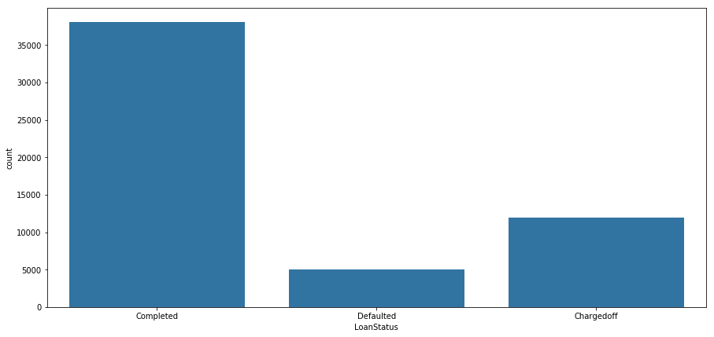

```python
plt.figure(figsize=[15,7])
sb.countplot(data=df, x='LoanStatus', color=sb.color_palette()[0]);
```

```python
df.LoanStatus.value_counts()
```

```
Completed     38043
Chargedoff    11992
Defaulted      5017
Name: LoanStatus, dtype: int64
```

As both Defaulted and Chargedoff are loans that have been failed to be payed back, we can combine these into a 'Failed' variable. This makes comparing completed and failed loans easier.

```python
status_dict = {'Completed' : 'Completed', 'Defaulted' : 'Failed', 'Chargedoff' : 'Failed'}

df['LoanStatusM'] = df['LoanStatus'].map(status_dict)

df.LoanStatusM.value_counts()
```

```
Completed    38043
Failed       17009
Name: LoanStatusM, dtype: int64
```

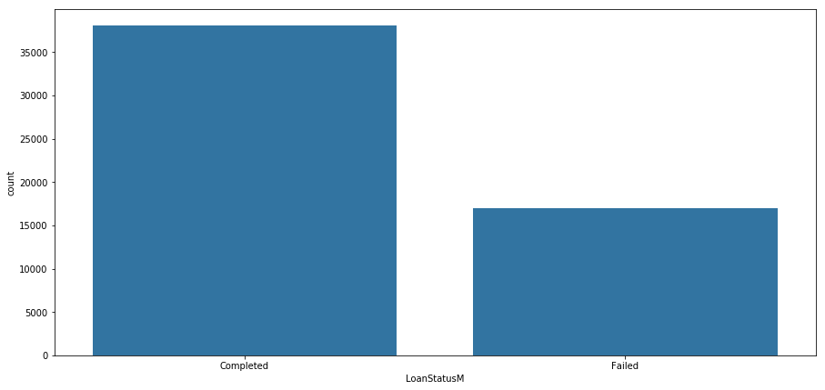

```python
plt.figure(figsize=[15,7])
sb.countplot(data=df, x='LoanStatusM', color=sb.color_palette()[0]);
```

```python
df.LoanStatusM.value_counts(normalize=True)
```

```
Completed    0.691038
Failed       0.308962
Name: LoanStatusM, dtype: float64
```

We can see that of all loans that are not currently still going, approximately a third fails. This seems very high.

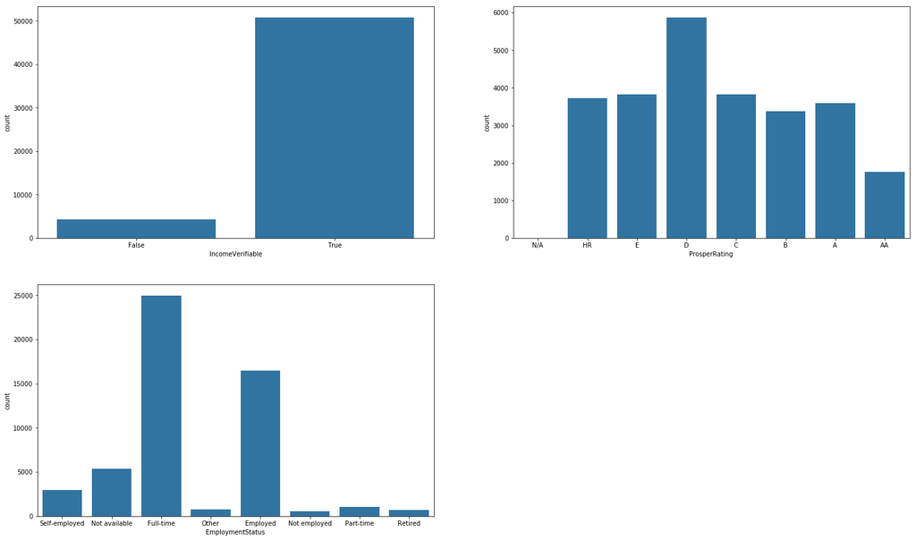

```python
plt.figure(figsize=[25,15])

plt.subplot(2,2,1)
sb.countplot(data=df, x='IncomeVerifiable', color=sb.color_palette()[0]);

plt.subplot(2,2,2)
sb.countplot(data=df, x='ProsperRating', color=sb.color_palette()[0]);

plt.subplot(2,2,3)
sb.countplot(data=df, x='EmploymentStatus', color=sb.color_palette()[0]);
```

When looking at the first graph it is clear that almost all incomes are verifiable. This is to be expected as it would seem unwise to loan money to someone who can't verify his income.

The prosper rating is slightly skewed to the right and unimodal. I would have expected the AA rating to be a lot more popular.

When looking at the third graph it is clear that most people are employed. This is also to be expected, as loaning out money to people who don't work does not seem wise.

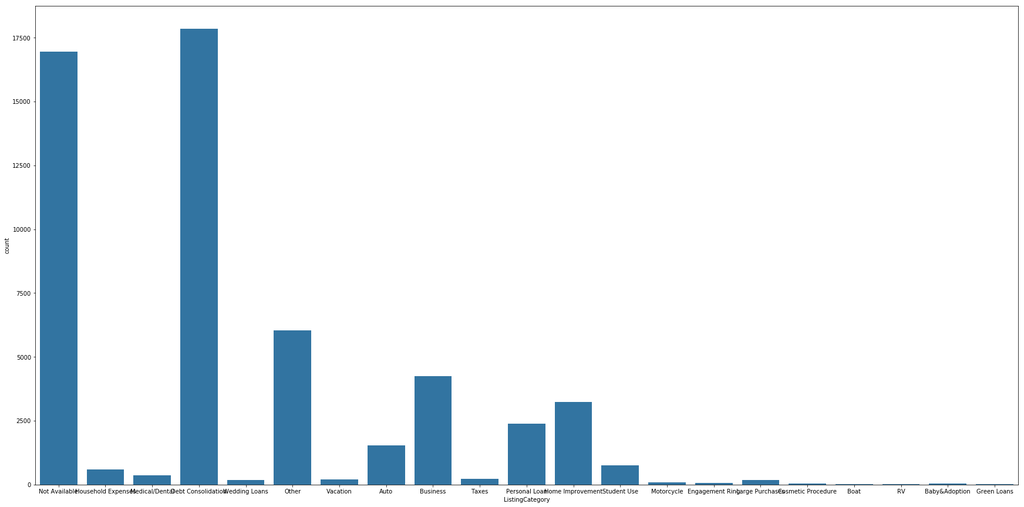

```python
plt.figure(figsize=[30,15])
sb.countplot(data=df, x='ListingCategory', color=sb.color_palette()[0]);
```

A lot of entries are missing, as there are a lot of 'Not available' values. The most popular reason to take a loan is 'Debt Consolidation'. All other reasons seem quite varied.

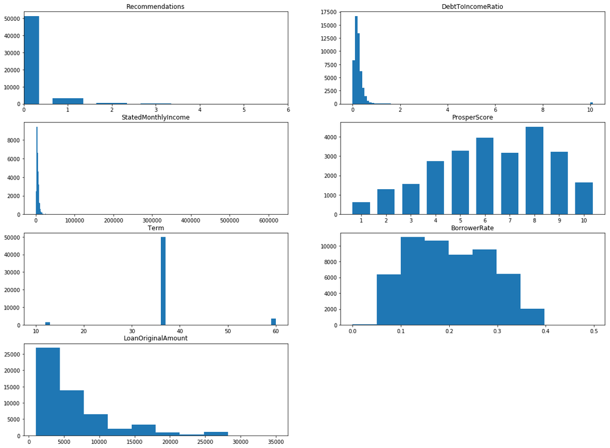

```python
plt.figure(figsize=[20,15])

plt.subplot(4,2,1)
bins = np.arange(-2.5, df.Recommendations.max()+1.5, 1)
plt.hist(data=df, x='Recommendations', bins=bins, rwidth=0.7);
plt.xticks(np.arange(0,df.Recommendations.max()+1, 1))
plt.xlim((0,6));
plt.title('Recommendations')

plt.subplot(4,2,2)
bins = np.arange(0, df.DebtToIncomeRatio.max()+0.1, 0.1)
plt.hist(data=df, x='DebtToIncomeRatio', bins=bins);
plt.title('DebtToIncomeRatio');

plt.subplot(4,2,3)
bins = np.arange(0, df.StatedMonthlyIncome.max()+1000, 1000)
plt.hist(data=df, x='StatedMonthlyIncome', bins=bins)
plt.title('StatedMonthlyIncome');

plt.subplot(4,2,4)
bins = np.arange(0.5,df.ProsperScore.max()+1.5,1)
plt.hist(data=df, x='ProsperScore', bins=bins, rwidth=0.7)
plt.xticks(np.arange(1, df.ProsperScore.max()+1, 1));
plt.title('ProsperScore');

plt.subplot(4,2,5)
bins = np.arange(10, df.Term.max()+1, 1)
plt.hist(data=df, x='Term', bins=bins);
plt.title('Term');

plt.subplot(4,2,6)
plt.hist(data=df, x='BorrowerRate');
plt.title('BorrowerRate');

plt.subplot(4,2,7)
plt.hist(data=df, x='LoanOriginalAmount');
plt.title('LoanOriginalAmount');
```

**Recommendations**: heavily skewed to the right, almost everyone has zero recommendations. Has a couple of outliers (hence the xlim).

**DebToIncomeRatio**: outliers at 10, needs further examining.

**StatedMonthlyIncome**: outliers, needs further examining.

**ProsperScore**: appears to be skewed to the left. Does not match the ProsperRating graph.

**Term**: there seem to be only 3 different terms: 12, 36, 60. Because of this, it might be better to see this variable as categoric instead of numeric.

**BorrowerRate**: seems to be skewed slightly to the right.

**LoanOriginalAmount**: this graph is heavily skewed to the right. There are no clear outliers and loans start quite low at $1000.

Let's take a closer look at DebtToIncomeRatio and StatedMonthlyIncome

```python
df.DebtToIncomeRatio.describe()
```

```
count    50824.000000
mean         0.289928
std          0.736948
min          0.000000
25%          0.130000
50%          0.200000
75%          0.300000
max         10.010000
Name: DebtToIncomeRatio, dtype: float64
```

We can see that there are some clear outliers, it could be interesting to see how many loans get completed that have a DebtToIncomeRatio that is higher than 9.

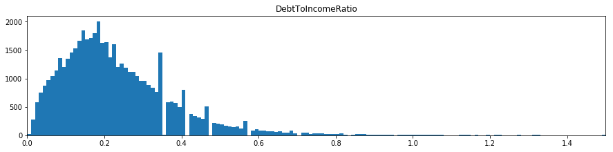

```python
plt.figure(figsize=[15,7])
plt.subplot(2,1,1)
bins = np.arange(0, df.DebtToIncomeRatio.max()+0.01, 0.01)
plt.hist(data=df, x='DebtToIncomeRatio', bins=bins);
plt.xlim((0,1.5))
plt.title('DebtToIncomeRatio');
```

```python
df.StatedMonthlyIncome.describe()
```

```
count     55052.000000
mean       5052.846777
std        5711.309384
min           0.000000
25%        2806.625000
50%        4166.666667
75%        6250.000000
max      618547.833333
Name: StatedMonthlyIncome, dtype: float64
```

Again we see clear outliers to the right. It will be interesting to see if these outliers take out much larger loans than the average and if they are better at completing their loans.

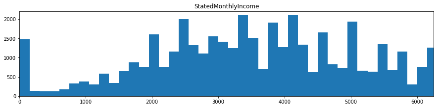

```python
plt.figure(figsize=[15,7])
plt.subplot(2,1,2)
bins = np.arange(0, df.StatedMonthlyIncome.max()+150, 150)
plt.hist(data=df, x='StatedMonthlyIncome', bins=bins)
plt.xlim((0, 6250)) # cap at the 75 percentile
plt.title('StatedMonthlyIncome');
```

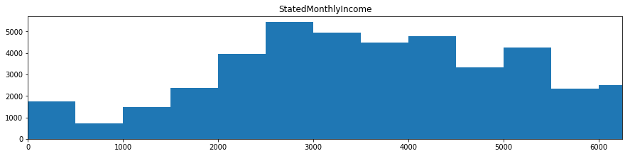

```python
plt.figure(figsize=[15,7])
plt.subplot(2,1,2)
bins = np.arange(0, df.StatedMonthlyIncome.max()+500, 500)
plt.hist(data=df, x='StatedMonthlyIncome', bins=bins)
plt.xlim((0, 6250)) # cap at the 75 percentile
plt.title('StatedMonthlyIncome');
```

Except for some local minima and maxima and a peak at zero, the graph seems to be a very wide normal distribution. This can be seen more clearly in the second graph with bins of size 500. It even seems to be slightly skewed to the right.

Both graphs seem to be unimodal, although StatedMonthlyIncome has a peak at zero. This could be caused by loans that don't have a verified income.

### Discuss the distribution(s) of your variable(s) of interest. Were there any unusual points? Did you need to perform any transformations?

After ordening the ProsperRating variable, the bar chart had a normal distribution which was skweded slightly to the right. This was surprising as you would expect that less risky loans would be more popular.

The StatedMonthlyIncome variable will also be interesting to examine further, as it has a lot of outliers.

ListingCategory has a lot of 'Not Available' values, thus will probably not be used anymore in this analysis.

## Bivariate Exploration

The bivariate exploration will start with looking at pairwise correlations present between features in the dataset.

```python
# The variables will be split into two categories: numeric and categoric.
# Note that Term will be used as a categoric variable and that the ListingCategory will no longer be used.

numeric_vars = ['Recommendations', 'DebtToIncomeRatio', 'StatedMonthlyIncome', 'ProsperScore',
               'BorrowerRate', 'LoanOriginalAmount']
categoric_vars = ['LoanStatus', 'LoanStatusM', 'IncomeVerifiable', 'ProsperRating', 'EmploymentStatus', 'Term']
```

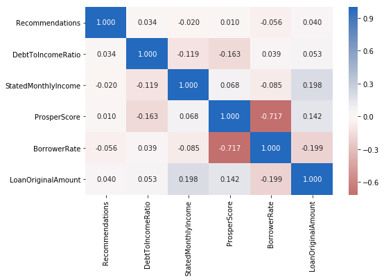

```python
# Correlation_plot
plt.figure(figsize = [8, 5])
sb.heatmap(df[numeric_vars].corr(), annot = True, fmt = '.3f',
           cmap = 'vlag_r', center = 0)
plt.show()
```

```python
# When trying to plot the plot matrix, some errors occurred because of nan values.
# Define: all rows containing nan values in a numeric_var column will be dropped.

# Code:

df.dropna(subset=numeric_vars, inplace=True)

# Test:

for var in numeric_vars:
    print(df[var].isna().sum())
```

```
0
0
0
0
0
0
```

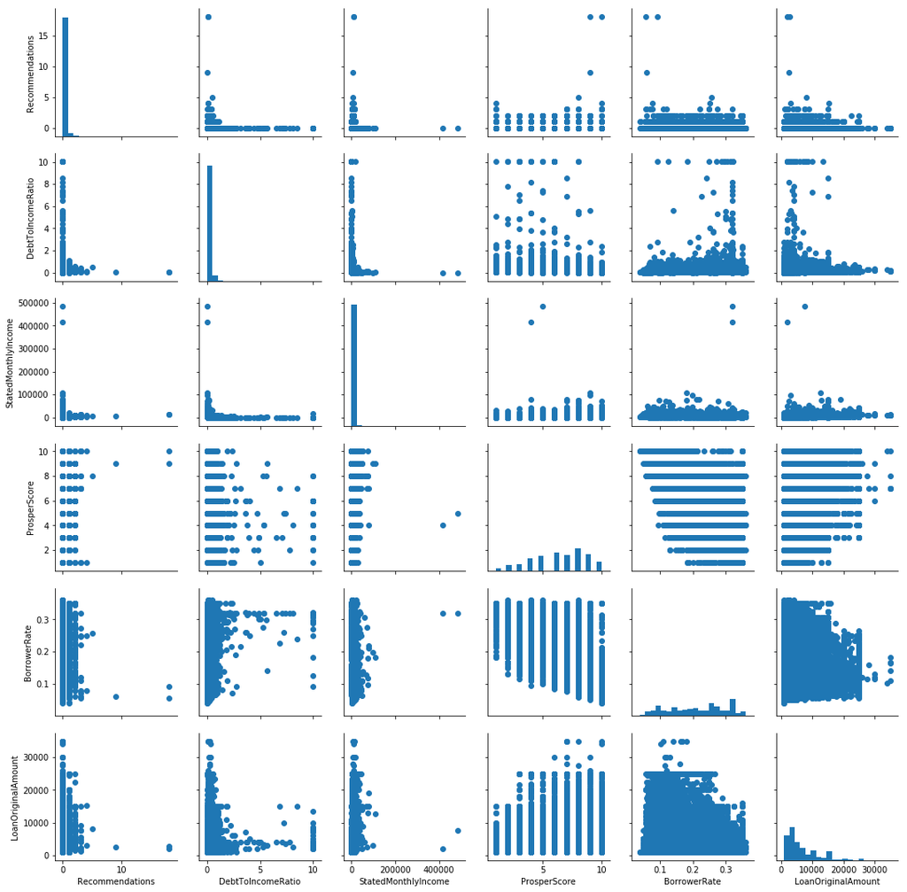

```python
g = sb.PairGrid(data = df, vars = numeric_vars);
g = g.map_diag(plt.hist, bins = 20);
g.map_offdiag(plt.scatter);
```

[output not shown]

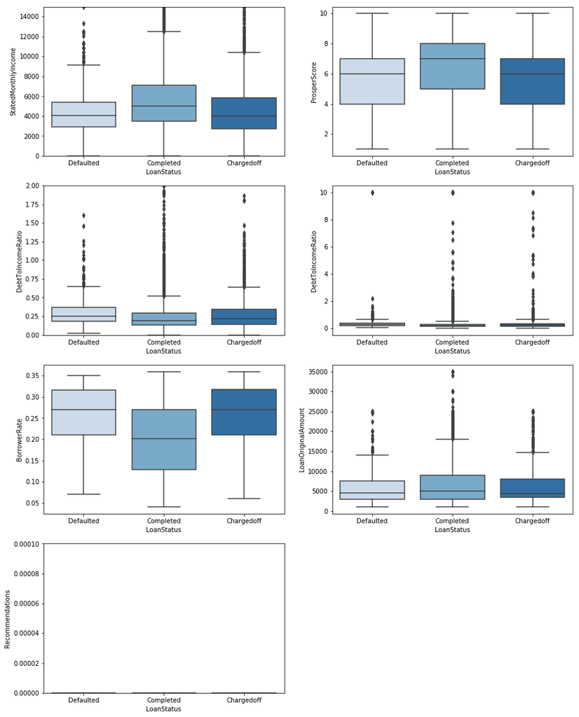

```python
plt.figure(figsize = [15, 20])

plt.subplot(4, 2, 1)
sb.boxplot(data = df, x = 'LoanStatus', y = 'StatedMonthlyIncome', palette = 'Blues')
plt.ylim((0,15000))

plt.subplot(4,2,2)
sb.boxplot(data = df, x = 'LoanStatus', y = 'ProsperScore', palette = 'Blues')

plt.subplot(4,2,3)
sb.boxplot(data = df, x = 'LoanStatus', y = 'DebtToIncomeRatio', palette = 'Blues')
plt.ylim((0,2))

plt.subplot(4,2,4)
sb.boxplot(data = df, x = 'LoanStatus', y = 'DebtToIncomeRatio', palette = 'Blues')

plt.subplot(4,2,5)
sb.boxplot(data = df, x = 'LoanStatus', y = 'BorrowerRate', palette = 'Blues')

plt.subplot(4,2,6)
sb.boxplot(data = df, x = 'LoanStatus', y = 'LoanOriginalAmount', palette = 'Blues')

plt.subplot(4,2,7)
sb.boxplot(data = df, x = 'LoanStatus', y = 'Recommendations', palette = 'Blues')
plt.ylim((0,0.0001))
```

There are multiple thing to note here.

**ProperScore**: the median ProperScore is also higher for loans that are completed. Which again confirms earlier expectations.

**DebtToIncomeRatio**: 2 graphs were used, one with a y-limit and one without. While very close, the median and 75th percentile of DebtToIncomeRatio of completed loans are lower than those of defaulted or charged off loans. There are a lot of outliers though.

**BorrowerRate**: it is clear that completed loans have lower BorrowerRates.

**LoanOriginalAmount**: loans that are completed have a larger range of original amounts loaned. But the median of completed, defaulted and chargedoff are very similar.

**Recommendations**: almost all loans have 0 recommendations, if we wan't to further examine this variable it might be better to seperate the loans with zero recommendations and the ones with more than zero recommendations.

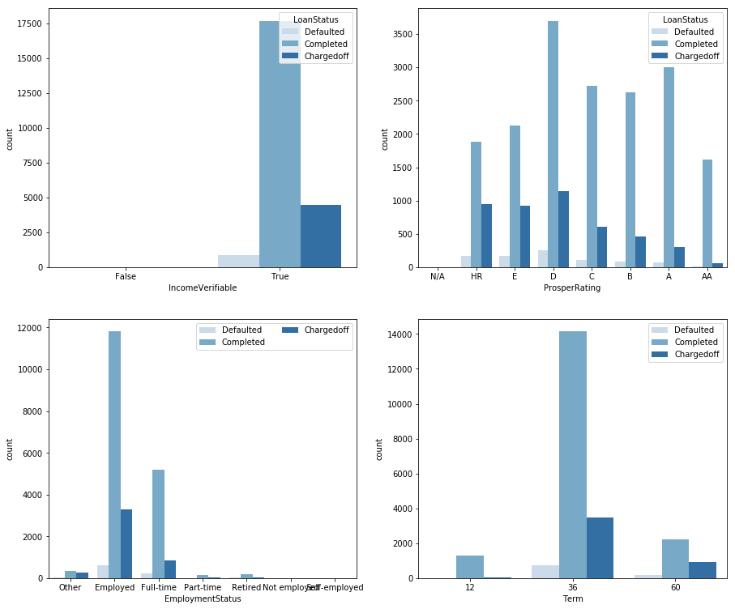

```python
# since there's only three subplots to create, using the full data should be fine.
plt.figure(figsize = [15, 20])

# subplot 1: IncomeVerifiable vs. LoanStatus
plt.subplot(3, 2, 1)
sb.countplot(data = df, x = 'IncomeVerifiable', hue = 'LoanStatus', palette = 'Blues')

# subplot 2: ProsperRating vs. LoanStatus
ax = plt.subplot(3, 2, 2)
sb.countplot(data = df, x = 'ProsperRating', hue = 'LoanStatus', palette = 'Blues')
#ax.legend(ncol = 2) # re-arrange legend to reduce overlapping

# subplot 3: EmploymentStatus vs. LoanStatus
ax = plt.subplot(3, 2, 3)
sb.countplot(data = df, x = 'EmploymentStatus', hue = 'LoanStatus', palette = 'Blues')
ax.legend(loc = 1, ncol = 2) # re-arrange legend to remove overlapping

# subplot 3: EmploymentStatus vs. LoanStatus
ax = plt.subplot(3, 2, 4)
sb.countplot(data = df, x = 'Term', hue = 'LoanStatus', palette = 'Blues')
ax.legend(loc = 1, ncol = 1) # re-arrange legend to remove overlapping

plt.show()
```

**IncomeVerifiable**: this are so few incomes that aren't verifiable that nothing new can be concluded out of this graph.

**ProsperRating**: AA rating has the lowest amount of chargedoff and defaulted loans, even relative to their amount of loans. The D rating has the highest amount of completed loans, which is probably caused by the fact that it is the most popular rating. Looking at this graph comparatively will give us a better insight.

**EmploymentStatus**: not much can be derived here, because the values of unemployment are so low.

**Term**: it is clear that the 36 term is the most popular and has the most absolute completed loans. We should investigate if this is also relatively the case.

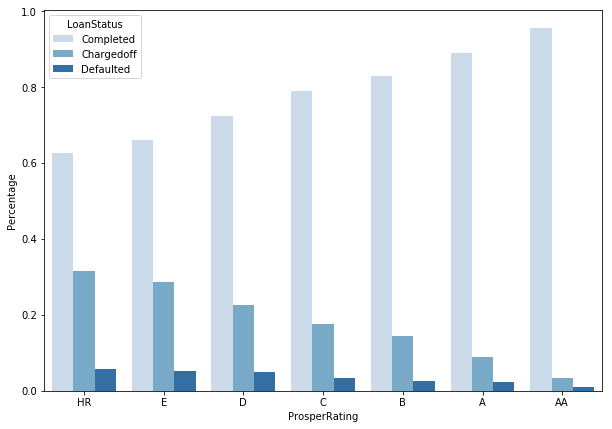

```python
# For each rating, the percentage of completed, chargedoff and defaulted will be shown. Thus the total sum of each rating is 1.
ratings = ['N/A', 'HR', 'E', 'D', 'C', 'B', 'A', 'AA']
df_ProsperRating = pd.DataFrame()

plt.figure(figsize=[10,7])
for rating in ratings:
    temp = df[df['ProsperRating'] == rating]['LoanStatus'].value_counts(normalize=True).rename_axis('LoanStatus').reset_index(name='Percentage')
    temp['ProsperRating'] = rating
    frames = [df_ProsperRating, temp]
    df_ProsperRating = pd.concat(frames)

sb.barplot(x="ProsperRating", y="Percentage", hue="LoanStatus", data=df_ProsperRating, palette='Blues');
```

We can see a clear trend, as the rating increases, the relative amount of completed loans increases and the amount of failed loans decreases.

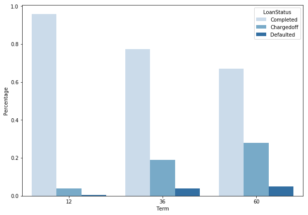

```python
terms = [12, 36, 60]
df_Term = pd.DataFrame()

plt.figure(figsize=[10,7])
for term in terms:
    temp = df[df['Term'] == term]['LoanStatus'].value_counts(normalize=True).rename_axis('LoanStatus').reset_index(name='Percentage')
    temp['Term'] = term
    frames = [df_Term, temp]
    df_Term = pd.concat(frames)

sb.barplot(x="Term", y="Percentage", hue="LoanStatus", data=df_Term, palette='Blues');
```

We can see that how higher the amount of terms, the higher the chance that a loan will not be completed.

### Talk about some of the relationships you observed in this part of the investigation. How did the feature(s) of interest vary with other features in the dataset?

We have discovered a couple of variables that have a positive impact on the chance that a loan gets completed: StatedMonthlyIncome, ProsperScore and ProsperRating should all be as high as possible.

A couple of variables have a negative impact: BorrowerRate and Term length should be kept as low as possible.

## Multivariate Exploration

The multivariate exploration process will be used to confirm the already found observations.

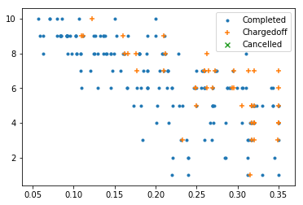

```python
sample = df.sample(frac=0.01, replace=True)

markers = [['Completed', '.'], ['Chargedoff', '+'], ['Cancelled', 'x']]

for status, marker in markers:
    df_marked = sample[sample['LoanStatus'] == status]
    plt.scatter(data = df_marked, x = 'BorrowerRate', y = 'ProsperScore', marker = marker)
plt.legend(['Completed','Chargedoff', 'Cancelled']);
```

### Talk about some of the relationships you observed in this part of the investigation. Were there features that strengthened each other in terms of looking at your feature(s) of interest?

No new relationships were observerd. Observations that were already made were confirmed by the multivariate plots.

### Were there any interesting or surprising interactions between features?

Nohing new was found.